# Spatial Regression Analysis Advanced Data Analytics

BIOL 5700, Fall 2019

# 1 Introduction to Spatial Regression

In this exercise we will cover the basics of spatial regression analysis including a discussion on spatial weight matrices, spatial models, model comparisons, and finally displaying the results using bivariate maps. To start, we will discuss the different ways to develop spatial weights for spatial regression analyses. These models were designed to address underlying spatial patterns in our data. Remember that one assumption of regression anlysis is independence of the observations. If the observations are spatially autocorrelated (a measure of similarity or correlation between nearby observations), estimates of the coefficients and the error terms may not be detectable from random noise.

## 1.1 Spatial Weights

Spatial weights describes the various ways that “neighbors” are determined in a spatial analysis. Tobler’s **First Law of Geography** (Waldo Tobler, 1970) states that,

> “everything is related to everything else, but near things are more related than distant things.”

While “*related*” should likely be restated as “*similar*”, this forms the basis for spatial autocorrelation and spatial interpolation analyses. With this in mind, we can look at the basic ways “neighborhoods” can be determined in a spatial analysis. In this exercise we will examine two common methods: contiguity (common boundaries) and distance (K-nearest neighbors).

### 1.1.1 Contiguity

Contiguity generally describes neighbors as individuals with shared or common boundary. In the example below, we see a hypothetical dataset with six individual polygons.

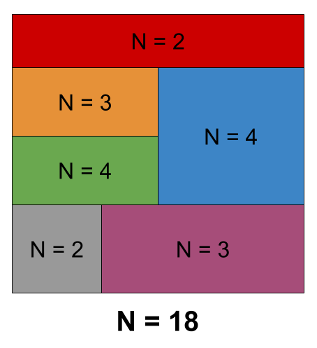

The six polygons contain a total of eighteen (18) neighbors within the neighborhood. The number of individual neighbors is identified within each polygon. Additionally, we can define how neighbor borders are identified.

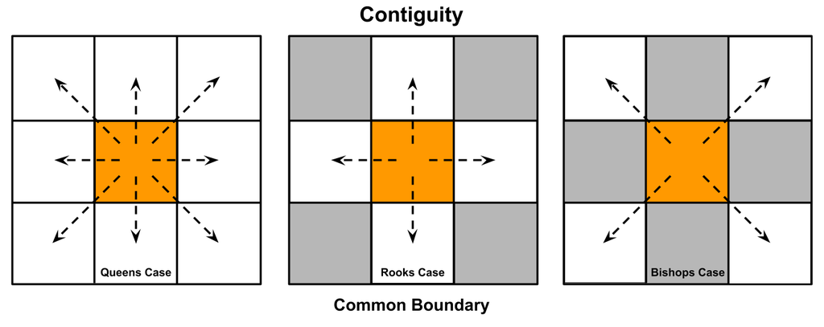

In the example above we can see the designation of neighbors can be identified by horizontal/vertical cases (rooks), diagonal cases (bishops), or in all cases (queens) along a regular grid. In irregular polygons, rooks neighbors are connected along edges, bishop neighbors by points, and queens neighbors by both points and edges. So in this example, the neighborhood established using the **queens case** contains eight (8) neighbors, four (4) neighbors by edges in the **rooks case**, and four (4) neighbors by points in the **bishops case**.

### 1.1.2 Distance

Neighbors can also be assigned by distance or K-nearest neighbors. Using this method, distance is measured from the centroid of a polygon until a specific number of neighbors are achieved.

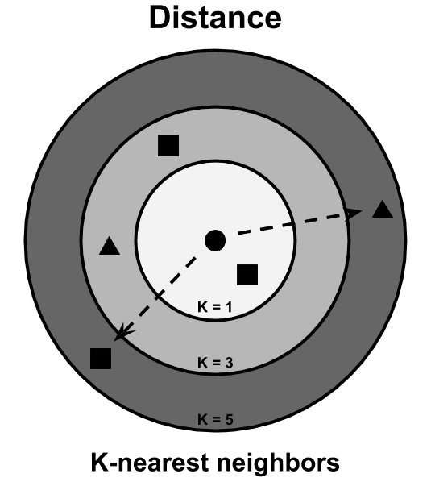

In the distance example, the K-value is equal to the number of individuals designated as neighbors. Within the **K = 1** circle, the neighborhood is identified as the single closest neighbor. **K = 3** contains the three (3) nearest neighbors and **K = 5** contains the five (5) nearest neighbors.

## 1.2 Basic Spatial Regression Models

During the first half of this course we examined ordinary least squares (OLS), generalized linear model (GLM), and linear mixed models. In this exercise we will look at some basic spatial regression models including: spatially lagged x - explanatory variable(s), spatial lag model, and spatial error model. Additionally, we will discuss spatial durbin and spatial durbin error nested models.

### 1.2.1 Spatially Lagged X Variable(s)

In a non-spatial OLS model, $y = X \beta + \varepsilon$, we examine the relationship between one or more independent variables and a dependent variable. With a spatially lagged, or SLX model, we see an addition of a spatial component to the equation that accounts for the average value of neighboring X values.

> $y = X \beta + WX\theta + \varepsilon$, where $WX\theta$ is the average value of our neighbors independent variable(s)

So the SLX equation examines whether variables that impact our neighbors also impact us. This is consdiered a *local model* as there is only one-way interaction between our neighbors and us.

### 1.2.2 Spatial Lag Model

In the Spatial Lag model, we lose the lagged X values that were used in the SLX model and instead add a spatially lagged y value.

> $y = \rho W y + X \beta + \varepsilon$, where $\rho W y$ is the spatially lagged y value of our neighbors

In this *global model* the dependent variable among our neighbors influences our dependent variable. Therefore there is a feedback loop that occurs where affects on our neighbor(s) y affects our y and our neighbor(s) y variable.

### 1.2.3 Spatial Error Model

The Spatial Error model does not include lagged dependent or independent variables, but instead includes a function of our unexplained error and that of our neighbors.

> $y = X \beta + u$, $u = \lambda W u + \varepsilon$, where $\lambda W u + \varepsilon$ is the function of our unexplained error (residuals) and our neighbors residual values

This is a *global model* where the higher than expected residual values suggest a missing explanatory variable that is spatially correlated. This would lead to unexplained clusters of spatially correlated values within our neighborhood that were not included as a predictor variable(s).

## 1.3 Nested Spatial Regression Models

In addition to the models discussed above, we can also examine a modern approach to model specifications. These nested models contain some lagged and/or error values and can be local or global models. These can be seen as exploratory analyses that use likelihood ratio tests to help infere the most appropriate model for our data. However, you must begin with an understanding of whether the relationships in your data are local or global in nature.

### 1.3.1 Spatial Durbin Model

The Spatial Durbin model includes both lagged y and lagged x values. This model can be simplified into *global* SLX, Spatial Lag, Spatial Error models, or OLS.

> $y = \rho Wy + X\beta + WX\theta + \varepsilon$

Because of the inclusion of the lagged y, this model would be used if the relationships in your data are global, meaning that if the y variable is impacted in one region that impact will spill over to every region in the dataset.

### 1.3.2 Spatial Durbin Error Model

This nested model does not contain a lagged y and can be simplified into a *local* Spatial Error, SLX, or OLS model.

> $y = X\beta + WX\theta + u$, $u = \lambda Wu + \varepsilon$

This nested model would be used if the relationships in your data are local, meaning changes in one region will only impact the immediate neighbors of the region and not all of the regions in the dataset.

# 2 Spatial Regression

With this basic knowledge of spatial regression and the associated models, we can now examine a dataset to:

1. Explore the data using OLS
2. Determine the presence of spatial autocorrelation
3. Choose appropriate spatial weights
4. Run spatial regression models
5. Plot the results

This will be a very code dense exercise due to the complexity of the analysis and the amount of data required to complete all of the steps listed above. Try to keep your naming conventions straight-forward so you can easily track down the data you need. When creating your own script and markdown document, consider adding descriptive text to convey the purpose of the specific analysis.

## 2.1 Packages used in this exercise

There are several specialty packages that will be used in this exercise due to the specific nature of the analyses. Some of these packages you will need to install while several others we have used in previous exercises and should already be installed.

|`cowplot` | `dplyr` | `geosphere` | `ggplot2` | `ggExtra` | `maps` |  
| `maptools` | `readxl` | `rgdal` | `rgeos` | `sf` | `sp` |  
|`spatialreg` | `spdep` | `tidyr` | `viridis`|

To begin, we will install the following:

```r
packages<-c("cowplot", "dplyr", "geosphere", "ggplot2", "ggExtra", "maps", "maptools", "readxl", "rgdal", "rgeos", "sf", "sp", "spatialreg", "spdep", "tidyr", "viridis")
sapply(packages, require, character.only=T)
```

[output not shown]

You may notice we loaded a number of packages that are included in the `tidyverse` package. Occasionally packages may mask functions needed from other packages. You can require the use of a function through a specific pacage by using a syntax such as `raster::crop()`. You can also create a selective functon to like `raster <- raster::crop` to require the use of a function from a specific package. Because we only needed a couple packages we just added them individually. Because of the significant amount of script involved in this exercise, you may need to refer to the help menu (e.g. `?poly2nb`) for additional information regarding specific functions used throughout the analysis.

## 2.2 Dataset

Generally we have been using biological data for each analysis. In this exercise we will examine the effect of numerous socioeconomic factors related to percentage of children under the age of 18 who are living below the poverty line in the Southern United States. Data for this analysis was collected from the U.S. Census Bureau, American Community Survey, Bureau of Labor Force Statistics, U.S. Department of Agriculture Economic Research Service, and the County Health Rankings. Independent variables include: rural, urban, manufacturing, agriculture, retail, healthcare, construction, less than high school degree, unemployment, income ratio, teen birth, unmarried, single mother, uninsured, as well as race variable like Black and Hispanic. Because this data has to be downloaded we will need to go through the process of importing this information using the `read.csv()` command. Once we have imported the data we can view the structure.

> If forked, this data will be available in the **Data** folder within the [repository](https://github.com/chrismgentry/Spatial-Regression).

In previous exercises, we used a simple implementation of `read.csv()` to import the dataset. However, this can occasionally prove to be problematic as columns can take on formatting that doesn’t necessarily fit the data. So in this example we will designate the format for each column.

```r
data <- read.csv('./Data/childpov18_southfull.csv',
                   colClasses = c("character", "character", "character",
                                  "numeric", "numeric", "numeric", "numeric",
                                  "numeric", "numeric", "numeric", "numeric",
                                  "numeric", "numeric", "numeric", "numeric",
                                  "numeric", "numeric", "numeric", "numeric",
                                  "numeric", "numeric", "numeric", "numeric",
                                  "numeric", "numeric", "numeric", "numeric",
                                  "numeric", "numeric", "numeric", "numeric",
                                  "numeric", "numeric", "numeric", "numeric"))
```

Now we can view the data:

```r
head(data)
```

|  | FIPS | State | County_Name | Longitude | Latitude | X2016.child.poverty | unemployment_13 | per_lhs_13 | per_black_13 | per_hispanic_13 | per_ag_13 | per_construction_13 | per_manufacturing_13 | per_retail_13 | per_healthss_13 | per_singlemom_13 | urban | rural | lnchildpov | lnunemployment | lnlesshs | lnblack | lnhispanic | lnag | lnconstruction | lnmanufacturing | lnretail | lnhealthss | lnsinglemom | … |
| --- | --- | --- | --- | --- | --- | --- | --- | --- | --- | --- | --- | --- | --- | --- | --- | --- | --- | --- | --- | --- | --- | --- | --- | --- | --- | --- | --- | --- | --- | --- |
| 1 | 1001 | AL | Autauga County | -86.64130 | 32.53942 | 16.7 | 6.2 | 14.4 | 18.216257 | 2.486022 | 1.403685 | 5.802732 | 12.883820 | 13.527176 | 17.70899 | 11.703934 | 1 | 0 | 2.815409 | 1.824549 | 2.667228 | 2.902314 | 0.9106838 | 0.3391007 | 1.758329 | 2.555972 | 2.604701 | 2.874072 | 2.459925 | … |
| 2 | 1003 | AL | Baldwin County | -87.72480 | 30.74312 | 18.4 | 6.6 | 11.0 | 9.428477 | 4.447556 | 1.890959 | 8.936305 | 8.850907 | 14.643341 | 19.58423 | 8.431112 | 1 | 0 | 2.912351 | 1.887070 | 2.397895 | 2.243735 | 1.4923550 | 0.6370840 | 2.190122 | 2.180520 | 2.683986 | 2.974725 | 2.131929 | … |
| 3 | 1005 | AL | Barbour County | -85.39238 | 31.87734 | 44.8 | 10.2 | 26.3 | 46.308700 | 4.900992 | 3.242723 | 5.854024 | 23.287671 | 12.050514 | 20.07705 | 16.545694 | 0 | 0 | 3.802208 | 2.322388 | 3.269569 | 3.835330 | 1.5894380 | 1.1764130 | 1.767129 | 3.147924 | 2.489107 | 2.999578 | 2.806126 | … |
| 4 | 1007 | AL | Bibb County | -87.12752 | 33.00021 | 26.2 | 7.9 | 22.5 | 21.662125 | 1.946910 | 2.206432 | 9.598604 | 19.932685 | 14.198454 | 21.27898 | 11.036163 | 1 | 0 | 3.265759 | 2.066863 | 3.113515 | 3.075565 | 0.6662437 | 0.7913769 | 2.261618 | 2.992361 | 2.653133 | 3.057720 | 2.401177 | … |
| 5 | 1009 | AL | Blount County | -86.56705 | 33.98325 | 26.5 | 6.3 | 23.0 | 1.353626 | 8.330007 | 2.928525 | 9.902238 | 17.123615 | 11.283945 | 20.59526 | 7.748771 | 1 | 0 | 3.277145 | 1.840550 | 3.135494 | 0.302787 | 2.1198640 | 1.0744990 | 2.292761 | 2.840459 | 2.423381 | 3.025061 | 2.047534 | … |
| 6 | 1011 | AL | Bullock County | -85.71598 | 32.10607 | 45.1 | 9.4 | 32.2 | 70.854271 | 5.685837 | 11.138371 | 18.007851 | 19.332679 | 9.715407 | 13.49362 | 15.320218 | 0 | 0 | 3.808882 | 2.240710 | 3.471967 | 4.260625 | 1.7379780 | 2.4103960 | 2.890808 | 2.961797 | 2.273713 | 2.602217 | 2.729173 | … |

Notice that there are 35 different columns in this dataset. If you notice, one of the columns is labeled as X2016.child.poverty. This is because when imported, R does not permit columns names to begin with a numeric values. Therefore it will always put an X at the start of the column name. It is always good practice to view your data when imported to address any potential issues like column names or formats. To fix this, we can rename that specific column name:

```r
names(data)[names(data)=="X2016.child.poverty"] <- "child.pov.2016"
```

For this exercise we will subset the data in order to reduce the time and complexity of the analysis. We will select the state of Texas for this example.

> Try it yourself! Use the example below and run the analysis on another state.

```r
tx_pov <- data %>% subset(State == "TX")
```

For additional QA/QC, we can view a summary of our data to check for any missing data or errors.

```r
summary(tx_pov)
```

```
     FIPS              State           County_Name          Longitude          Latitude     child.pov.2016
 Length:254         Length:254         Length:254         Min.   :-106.24   Min.   :26.13   Min.   : 0.00
 Class :character   Class :character   Class :character   1st Qu.:-100.78   1st Qu.:30.13   1st Qu.:18.52
 Mode  :character   Mode  :character   Mode  :character   Median : -98.54   Median :31.79   Median :23.65
                                                          Mean   : -98.65   Mean   :31.66   Mean   :23.70
                                                          3rd Qu.: -96.57   3rd Qu.:33.18   3rd Qu.:28.88
                                                          Max.   : -93.74   Max.   :36.28   Max.   :56.50
 unemployment_13    per_lhs_13     per_black_13    per_hispanic_13    per_ag_13       per_construction_13
 Min.   : 2.600   Min.   : 6.60   Min.   : 0.000   Min.   : 2.233   Min.   : 0.5895   Min.   : 0.000
 1st Qu.: 5.000   1st Qu.:16.32   1st Qu.: 1.155   1st Qu.:16.632   1st Qu.: 4.8213   1st Qu.: 6.268
 Median : 5.800   Median :20.00   Median : 3.900   Median :24.625   Median : 9.1786   Median : 7.754
 Mean   : 6.126   Mean   :21.75   Mean   : 6.231   Mean   :32.938   Mean   :11.7818   Mean   : 8.250
 3rd Qu.: 6.700   3rd Qu.:25.65   3rd Qu.: 8.784   3rd Qu.:47.754   3rd Qu.:16.8112   3rd Qu.: 9.759
 Max.   :15.700   Max.   :55.00   Max.   :33.314   Max.   :98.432   Max.   :51.5464   Max.   :18.153
 per_manufacturing_13 per_retail_13    per_healthss_13  per_singlemom_13     urban            rural
 Min.   : 0.00        Min.   : 0.000   Min.   : 4.762   Min.   : 0.000   Min.   :0.0000   Min.   :0.0000
 1st Qu.: 4.43        1st Qu.: 9.182   1st Qu.:19.480   1st Qu.: 7.512   1st Qu.:0.0000   1st Qu.:0.0000
 Median : 7.53        Median :11.458   Median :22.204   Median : 9.586   Median :0.0000   Median :0.0000
 Mean   : 7.97        Mean   :10.897   Mean   :22.538   Mean   : 9.798   Mean   :0.3228   Mean   :0.1929
 3rd Qu.:10.82        3rd Qu.:12.727   3rd Qu.:25.636   3rd Qu.:12.183   3rd Qu.:1.0000   3rd Qu.:0.0000
 Max.   :29.45        Max.   :19.300   Max.   :38.697   Max.   :21.034   Max.   :1.0000   Max.   :1.0000
   lnchildpov     lnunemployment      lnlesshs        lnblack          lnhispanic          lnag
 Min.   :-4.605   Min.   :0.9555   Min.   :1.887   Min.   :-4.6052   Min.   :0.8034   Min.   :-0.5285
 1st Qu.: 2.919   1st Qu.:1.6094   1st Qu.:2.793   1st Qu.: 0.1442   1st Qu.:2.8113   1st Qu.: 1.5730
 Median : 3.163   Median :1.7579   Median :2.996   Median : 1.3610   Median :3.2038   Median : 2.2169
 Mean   : 2.995   Mean   :1.7684   Mean   :3.013   Mean   : 0.8919   Mean   :3.2347   Mean   : 2.1164
 3rd Qu.: 3.363   3rd Qu.:1.9021   3rd Qu.:3.245   3rd Qu.: 2.1729   3rd Qu.:3.8661   3rd Qu.: 2.8220
 Max.   : 4.034   Max.   :2.7537   Max.   :4.007   Max.   : 3.5060   Max.   :4.5894   Max.   : 3.9425
 lnconstruction   lnmanufacturing     lnretail        lnhealthss     lnsinglemom       lnchpov17
 Min.   :-4.605   Min.   :-4.605   Min.   :-4.605   Min.   :1.561   Min.   :-4.605   Min.   :-4.600
 1st Qu.: 1.835   1st Qu.: 1.488   1st Qu.: 2.217   1st Qu.:2.969   1st Qu.: 2.017   1st Qu.: 2.800
 Median : 2.048   Median : 2.019   Median : 2.439   Median :3.100   Median : 2.260   Median : 3.125
 Mean   : 2.031   Mean   : 1.776   Mean   : 2.323   Mean   :3.089   Mean   : 2.155   Mean   : 2.940
 3rd Qu.: 2.278   3rd Qu.: 2.381   3rd Qu.: 2.544   3rd Qu.:3.244   3rd Qu.: 2.500   3rd Qu.: 3.342
 Max.   : 2.899   Max.   : 3.383   Max.   : 2.960   Max.   :3.656   Max.   : 3.046   Max.   : 4.132
  lnuninsured    lnincome_ratio  lnsevere_housing  lnteenbirth     lnunmarried
 Min.   :2.642   Min.   :1.158   Min.   :0.010    Min.   :2.507   Min.   :0.010
 1st Qu.:3.155   1st Qu.:1.454   1st Qu.:2.445    1st Qu.:3.909   1st Qu.:3.120
 Median :3.244   Median :1.532   Median :2.624    Median :4.114   Median :3.523
 Mean   :3.238   Mean   :1.534   Mean   :2.595    Mean   :4.080   Mean   :3.230
 3rd Qu.:3.333   3rd Qu.:1.606   3rd Qu.:2.800    3rd Qu.:4.317   3rd Qu.:3.859
 Max.   :3.653   Max.   :2.267   Max.   :3.473    Max.   :4.852   Max.   :4.605
```

## 2.3 Ordinary Least Squares

We are going to begin this analysis by writing a script to define our equation with an assignment operator followed by our variables. This will keep us from having to copy and paste the equation repeatedly throughout the analysis.

```r
equation <- child.pov.2016 ~ rural + urban + lnmanufacturing + lnag +
            lnretail + lnhealthss + lnconstruction + lnlesshs +
            lnunemployment + lnsinglemom + lnblack + lnhispanic +
            lnuninsured + lnincome_ratio + lnteenbirth + lnunmarried
```

This equation will be used to explain the level of child poverty by the list of variables and log variables in the dataset. We are also going to limit the use of scientific notation to numbers greater than 5 decimal places within the output and summaries. This is adjusted in the options:

```r
options(scipen = 5)
```

To test this relationship we will start by running a simple OLS.

```r
ols <- lm(equation, data=tx_pov)
summary(ols)
```

```
Call:
lm(formula = equation, data = tx_pov)

Residuals:
     Min       1Q   Median       3Q      Max
-22.2797  -3.7164   0.0318   3.9219  22.4168

Coefficients:
                 Estimate Std. Error t value Pr(>|t|)
(Intercept)     -86.50820   12.85507  -6.730 1.27e-10 ***
rural            -1.99975    1.50036  -1.333 0.183861
urban            -0.23421    1.25471  -0.187 0.852085
lnmanufacturing   0.12695    0.56070   0.226 0.821079
lnag             -1.10187    0.77451  -1.423 0.156149
lnretail         -1.28789    1.34550  -0.957 0.339448
lnhealthss        5.13853    2.03292   2.528 0.012134 *
lnconstruction   -2.60999    1.10021  -2.372 0.018479 *
lnlesshs          8.60026    2.64769   3.248 0.001330 **
lnunemployment    8.86334    1.95041   4.544 8.79e-06 ***
lnsinglemom       2.14337    0.92279   2.323 0.021042 *
lnblack          -0.66033    0.31448  -2.100 0.036811 *
lnhispanic       -1.26238    0.99343  -1.271 0.205072
lnuninsured      14.37337    3.91819   3.668 0.000301 ***
lnincome_ratio    6.00025    3.44936   1.740 0.083240 .
lnteenbirth       1.97988    1.29756   1.526 0.128380
lnunmarried      -0.04797    0.47643  -0.101 0.919884
---
Signif. codes:  0 ‘***’ 0.001 ‘**’ 0.01 ‘*’ 0.05 ‘.’ 0.1 ‘ ’ 1

Residual standard error: 6.965 on 237 degrees of freedom
Multiple R-squared:  0.5052,    Adjusted R-squared:  0.4718
F-statistic: 15.13 on 16 and 237 DF,  p-value: < 2.2e-16
```

In this analysis we can see a number of significant ($\alpha = 0.05$) log variables including: employment in healthcase or construction, less than high school education, rate of unemployment, single mother households, rate of uninsured individuals, and a single race variable. The model is also statistically significant with a p-value of < 2.2e-16.

## 2.4 Spatial Regression Analysis, Contiguity

Referring back to the section above on Contiguity, we know that neighbors are described as individuals with shared or common boundary. Those can be of several different cases including rook, bishop, and queen. In the example below, we run our analyses based on queens case neighbors.

### 2.4.1 Creating a list of contiguity neighbors

In order to determine if there is any underlaying spatial relationships in our residuals we can run a various tests of our data. However, in order to do this we need to provide a spatial weights matrix. So we need to run the following commands to create a list of neighbors. But before we need to create a county polygon dataset containing a variable, Federal Information Processing Standards codes (FIPS), that will eventually allow us to connect the poverty data if necessary.

```r
#Obtain FIPS Codes by county
fips <- county.fips

#Create county polygons
texas <- map(database = "county", regions = "texas", fill=T, plot=F)
IDs <- sub("^texas,","",texas$names)

#Add FIPS codes to the county polygons
fips.codes <- separate(data = fips, col = polyname, into = c("state", "county"), sep = ",")
tx_fips <- subset(fips.codes, state=="texas", select=fips)
names <- fips.codes$county
tx_IDs <- unique(tx_fips$fips)

#Create spatial polygons
tx_sp = map2SpatialPolygons(texas,tx_fips$fips,CRS("+proj=longlat"))
names(tx_sp@polygons) <- tx_IDs

#Create neighbor weights using the queens case
neighb.data <- poly2nb(tx_sp, queen=T)
names(neighb.data) <- names(tx_sp@polygons)

#Create list of neighbors
cont.neighb <- nb2listw(neighb.data,style="W", zero.policy = TRUE)
```

Now that we have created a spatial dataset and a list of neighbors, we can determine if there is any residual spatial dependence.

### 2.4.2 Moran’s Correlation and LaGrange Multiplier Tests

In this step we will use a Moran’s Correlation Test designed for regression residuals to examines the residuals of the OLS regression using the spatial relationship matrix. In this case the null hypothesis (H<sub>O</sub>) is “no spatial correlation in the residuals”.

```r
lm.morantest(ols, cont.neighb)
```

```
    Global Moran I for regression residuals

data:
model: lm(formula = equation, data = tx_pov)
weights: cont.neighb

Moran I statistic standard deviate = 3.0923, p-value = 0.0009931
alternative hypothesis: greater
sample estimates:
Observed Moran I      Expectation         Variance
     0.095560223     -0.016773540      0.001319666
```

In viewing the results from our Moran’s Test for regression residuals we see that we have a significant p-value of 0.00099. So we would reject the H<sub>O</sub> due to detection of spatial dependency in our dataset. This would suggest we should be using a spatial model.

Another way to analyze the data is to use a LaGrange Multiplier Test. The function reports the estimates of simple LM tests for error dependence (LMerr), for a missing spatially lagged dependent variable (LMlag), for robust variants of these tests (RLMerr to test for error dependence in the possible presence of a missing lagged dependent variable and RLMlag the other way round), and a portmanteau test (SARMA, in fact LMerr + RLMlag). We can run all of these at once using the following script:

```r
lm.LMtests(ols, cont.neighb, test="all")
```

```
    Lagrange multiplier diagnostics for spatial dependence

data:
model: lm(formula = equation, data = tx_pov)
weights: cont.neighb

LMerr = 6.3382, df = 1, p-value = 0.01182


    Lagrange multiplier diagnostics for spatial dependence

data:
model: lm(formula = equation, data = tx_pov)
weights: cont.neighb

LMlag = 5.809, df = 1, p-value = 0.01594


    Lagrange multiplier diagnostics for spatial dependence

data:
model: lm(formula = equation, data = tx_pov)
weights: cont.neighb

RLMerr = 1.0913, df = 1, p-value = 0.2962


    Lagrange multiplier diagnostics for spatial dependence

data:
model: lm(formula = equation, data = tx_pov)
weights: cont.neighb

RLMlag = 0.56209, df = 1, p-value = 0.4534


    Lagrange multiplier diagnostics for spatial dependence

data:
model: lm(formula = equation, data = tx_pov)
weights: cont.neighb

SARMA = 6.9003, df = 2, p-value = 0.03174
```

The results of the five (5) LaGrange Multiplier Tests are as follows:

| LMerr | LMlag | RLMerr | RLMlag | SARMA |
| --- | --- | --- | --- | --- |
| *0.012* | 0.016 | *0.296* | 0.453 | 0.032 |

Based on these results, the LaGrange Multiplier Tests suggests a spatial error or spatial lag model would improve the fit of our model. The robust models make an attempt to filter out the potential false positives in the data generation. I do not believe R has the ability to run a SARMA model and in statistics courses I have taken in the past, it was suggested that SARMA models are rarely appropriate no matter the P-value. I am not familiar enough with Seasonal Autoregressive Moving Average models to know when they are necessary. Based on the p-values in the table above, it is suggested that we continue with a spatial error model.

### 2.4.3 Spatially Lagged X Model

Although the results above indicated an error model would be the most appropriate model, here we will examine the Spatially Lagged X Model and later on the Spatial Lag Model. As described above, the SLX model Waccounts for the average value of neighboring X values within our model. Essentially this is a one-way interaction where potentially our neighbors have an impact on us, but that is the limit of the interactions. To run an SLX model we need to provide the dataset and the spatial weights matrix we create before.

```r
SLX.model <- lmSLX(equation, data=tx_pov, cont.neighb)
summary(SLX.model)
```

```
Call:
lm(formula = formula(paste("y ~ ", paste(colnames(x)[-1], collapse = "+"))),
    data = as.data.frame(x), weights = weights)

Residuals:
     Min       1Q   Median       3Q      Max
-22.2280  -3.7042  -0.3626   3.8252  19.7106

Coefficients:
                      Estimate Std. Error t value  Pr(>|t|)
(Intercept)         -127.06759   30.16906  -4.212 0.0000369 ***
rural                 -2.46167    1.59469  -1.544   0.12410
urban                  0.02043    1.34435   0.015   0.98789
lnmanufacturing       -0.09738    0.62167  -0.157   0.87567
lnag                  -0.73469    0.97278  -0.755   0.45091
lnretail              -0.69809    1.43939  -0.485   0.62816
lnhealthss             4.35219    2.33117   1.867   0.06323 .
lnconstruction        -2.18978    1.16544  -1.879   0.06157 .
lnlesshs               8.07940    2.98545   2.706   0.00734 **
lnunemployment         6.87451    2.18694   3.143   0.00190 **
lnsinglemom            2.41027    0.97739   2.466   0.01442 *
lnblack               -1.05893    0.39612  -2.673   0.00807 **
lnhispanic             1.19434    1.53993   0.776   0.43882
lnuninsured           10.42508    5.02773   2.074   0.03928 *
lnincome_ratio         6.29879    3.64999   1.726   0.08580 .
lnteenbirth            2.33871    1.35931   1.721   0.08674 .
lnunmarried            0.08268    0.51228   0.161   0.87193
lag.rural             -0.40666    3.80296  -0.107   0.91494
lag.urban             -0.95068    3.06209  -0.310   0.75650
lag.lnmanufacturing   -0.45707    1.23771  -0.369   0.71227
lag.lnag               0.08274    1.63159   0.051   0.95960
lag.lnretail           5.42065    3.54293   1.530   0.12745
lag.lnhealthss         9.20346    4.69963   1.958   0.05145 .
lag.lnconstruction    -3.43565    2.53190  -1.357   0.17618
lag.lnlesshs           0.06447    5.74321   0.011   0.99105
lag.lnunemployment     1.68346    4.89665   0.344   0.73133
lag.lnsinglemom       -3.68631    2.49604  -1.477   0.14114
lag.lnblack            0.73559    0.61437   1.197   0.23247
lag.lnhispanic        -2.09550    2.24940  -0.932   0.35257
lag.lnuninsured       -2.86477    8.42585  -0.340   0.73418
lag.lnincome_ratio     5.28207    8.10652   0.652   0.51535
lag.lnteenbirth        6.43891    3.71497   1.733   0.08445 .
lag.lnunmarried        0.14316    1.28215   0.112   0.91120
---
Signif. codes:  0 ‘***’ 0.001 ‘**’ 0.01 ‘*’ 0.05 ‘.’ 0.1 ‘ ’ 1

Residual standard error: 6.899 on 221 degrees of freedom
Multiple R-squared:  0.5473,    Adjusted R-squared:  0.4817
F-statistic: 8.349 on 32 and 221 DF,  p-value: < 2.2e-16
```

Notice that in the summary we see coefficients for our independent variables as well as those of our neighbors. Looking at the p-values we can see that lagged variables were not significant further emphasizing the need for an error model. If this was the suggested model for your data, a more informative way to view the results would be to examine the combined impacts of the x and lagged x variables. Using the `summary(impacts(SLX.model, cont.neighb, R=1000), zstats = TRUE)` script will produce a matrix of direct effect and indirect effect coefficients, z-scores, and p-values for the total impacts of each variable. However, I am going to use the following script to limit the results to only the p-values.

```r
summary(impacts(SLX.model, cont.neighb), zstats = TRUE)[["pzmat"]]
```

```
                     Direct   Indirect       Total
rural           0.122667918 0.91484305 0.474233470
urban           0.987877742 0.75620619 0.761587350
lnmanufacturing 0.875529947 0.71191528 0.670709149
lnag            0.450101365 0.95955529 0.666112355
lnretail        0.627682384 0.12601873 0.218455807
lnhealthss      0.061907517 0.05019031 0.002894118
lnconstruction  0.060253487 0.17479891 0.036700076
lnlesshs        0.006804617 0.99104369 0.131309506
lnunemployment  0.001669794 0.73099830 0.070568521
lnsinglemom     0.013661702 0.13971252 0.614504413
lnblack         0.007511418 0.23118307 0.549073423
lnhispanic      0.437995184 0.35155445 0.614754961
lnuninsured     0.038124147 0.73385842 0.304657969
lnincome_ratio  0.084401627 0.51467051 0.171734814
lnteenbirth     0.085338964 0.08305415 0.038675967
lnunmarried     0.871779473 0.91109405 0.880342268
```

Again we see that only a few variables are significant in this analysis.

### 2.4.4 Spatial Lag Model

Remember that the Spatial Lag Model is a global model where the dependent variable among our neighbors influences our dependent variable. Therefore there is a feedback loop that occurs where affects on our neighbor(s) y affects our y and our neighbor(s) y variable. Although we will move on the to appropriate error model in the next section, we can run the Spatial Lag Model to examine the results.

```r
sp.lag.model <- spatialreg::lagsarlm(equation, data=tx_pov, cont.neighb)
summary(sp.lag.model, Nagelkerke = TRUE)
```

```
Call:spatialreg::lagsarlm(formula = equation, data = tx_pov, listw = cont.neighb)

Residuals:
       Min         1Q     Median         3Q        Max
-20.771862  -3.818987  -0.058792   3.594372  22.145552

Type: lag
Coefficients: (asymptotic standard errors)
                   Estimate  Std. Error z value  Pr(>|z|)
(Intercept)     -83.3615111  12.2867007 -6.7847 1.163e-11
rural            -1.9341120   1.4333792 -1.3493 0.1772287
urban            -0.1509087   1.1967370 -0.1261 0.8996526
lnmanufacturing   0.1788383   0.5358207  0.3338 0.7385567
lnag             -0.8646923   0.7428990 -1.1639 0.2444470
lnretail         -1.2277641   1.2852621 -0.9553 0.3394444
lnhealthss        4.3264824   1.9521420  2.2163 0.0266727
lnconstruction   -2.3241879   1.0546191 -2.2038 0.0275372
lnlesshs          7.7875444   2.5550808  3.0479 0.0023047
lnunemployment    8.0523434   1.8984982  4.2414 2.221e-05
lnsinglemom       2.3046173   0.8801564  2.6184 0.0088338
lnblack          -0.5809891   0.3034813 -1.9144 0.0555672
lnhispanic       -1.1766409   0.9489231 -1.2400 0.2149846
lnuninsured      14.1425519   3.7377450  3.7837 0.0001545
lnincome_ratio    5.1385531   3.3041076  1.5552 0.1198981
lnteenbirth       1.7695359   1.2381580  1.4292 0.1529559
lnunmarried      -0.0094519   0.4544499 -0.0208 0.9834063

Rho: 0.16893, LR test value: 5.2078, p-value: 0.022485
Asymptotic standard error: 0.074846
    z-value: 2.2571, p-value: 0.024004
Wald statistic: 5.0944, p-value: 0.024004

Log likelihood: -841.9984 for lag model
ML residual variance (sigma squared): 44.115, (sigma: 6.6419)
Nagelkerke pseudo-R-squared: 0.51528
Number of observations: 254
Number of parameters estimated: 19
AIC: 1722, (AIC for lm: 1725.2)
LM test for residual autocorrelation
test value: 1.206, p-value: 0.27212
```

```r
#Where Rho is the spatially lagged y multiplier
```

We can see from the p-value (0.0224852) that model is significant with similar significant variables as in the OLS model. Again, due to the feedback loop, the summary table for this analysis is difficult to interpret because when our y increases, our neighbors y goes up as well, which then causes our y to increase. So once again we need to view the impact table.

```r
summary(impacts(sp.lag.model, listw = cont.neighb, R=100), zstats = TRUE)[["pzmat"]]
```

```
                       Direct   Indirect         Total
rural           0.17419880750 0.31497650 0.18448747028
urban           0.80257296777 0.81344408 0.80126003504
lnmanufacturing 0.79133461036 0.80710298 0.79108001727
lnag            0.25887041776 0.32147268 0.25043336106
lnretail        0.29923450154 0.40598751 0.30524327260
lnhealthss      0.00887588636 0.14071789 0.00969707862
lnconstruction  0.04302101540 0.19505873 0.03788898348
lnlesshs        0.00457215052 0.13417419 0.00370005432
lnunemployment  0.00001485268 0.08454821 0.00001148302
lnsinglemom     0.00523066463 0.15064217 0.00611385022
lnblack         0.04061087009 0.20077438 0.04568869904
lnhispanic      0.25151608155 0.38512309 0.25358477229
lnuninsured     0.00006332797 0.11572019 0.00038535403
lnincome_ratio  0.16826908755 0.28138116 0.16379945855
lnteenbirth     0.11042457423 0.31601640 0.11887272671
lnunmarried     0.93855443501 0.91869391 0.93363905911
```

```r
#Because this is a simulation, R details the number of repetitions.
```

As with the previous impacts table, I limted the results to the p-values, but you can see the full output table by using `summary(impacts(sp.lag.model, listw = cont.neighb, R=100)`. Because these are simulations, you may want to run the impacts table several times with a large number of repetitions to determine the stability of the results.

### 2.4.5 Spatial Error Model

Now we will run the Spatial Error Model that was suggested earlier in our analysis by the Moran’s Correlation and LaGrange Multiplier Tests. The Spatial Error Model does not include lagged dependent or independent variables, but instead includes a function of our unexplained error and that of our neighbors. In this analysis, higher than expected residual values suggest a missing explanatory variable that is spatially correlated.

```r
sp.err.model <- spatialreg::errorsarlm(equation, data=tx_pov, cont.neighb)
summary(sp.err.model, Nagelkerke = TRUE)
```

```
Call:spatialreg::errorsarlm(formula = equation, data = tx_pov, listw = cont.neighb)

Residuals:
      Min        1Q    Median        3Q       Max
-21.18297  -3.50397  -0.15273   3.68751  21.88176

Type: error
Coefficients: (asymptotic standard errors)
                  Estimate Std. Error z value  Pr(>|z|)
(Intercept)     -81.632091  12.895227 -6.3304 2.445e-10
rural            -2.239971   1.441003 -1.5545 0.1200764
urban            -0.057247   1.217828 -0.0470 0.9625072
lnmanufacturing   0.082049   0.547040  0.1500 0.8807747
lnag             -0.939302   0.786109 -1.1949 0.2321362
lnretail         -1.568230   1.276888 -1.2282 0.2193847
lnhealthss        4.244038   2.017342  2.1038 0.0353979
lnconstruction   -2.354845   1.060230 -2.2211 0.0263463
lnlesshs          8.622796   2.651494  3.2521 0.0011457
lnunemployment    8.590103   1.923615  4.4656 7.984e-06
lnsinglemom       2.467036   0.889356  2.7740 0.0055379
lnblack          -0.737356   0.321786 -2.2914 0.0219374
lnhispanic       -1.183896   1.045278 -1.1326 0.2573770
lnuninsured      14.233722   4.026419  3.5351 0.0004076
lnincome_ratio    5.447997   3.339481  1.6314 0.1028079
lnteenbirth       1.617612   1.203351  1.3443 0.1788654
lnunmarried      -0.018476   0.443282 -0.0417 0.9667542

Lambda: 0.26132, LR test value: 6.5162, p-value: 0.01069
Asymptotic standard error: 0.091697
    z-value: 2.8498, p-value: 0.0043747
Wald statistic: 8.1213, p-value: 0.0043747

Log likelihood: -841.3442 for error model
ML residual variance (sigma squared): 43.553, (sigma: 6.5994)
Nagelkerke pseudo-R-squared: 0.51777
Number of observations: 254
Number of parameters estimated: 19
AIC: 1720.7, (AIC for lm: 1725.2)
```

```r
#Where Lambda is the error multiplier
```

In the summary we see seven (7) significant log variables including: employment in healthcare and construction, less than high school education, rate of unemployment, single mother households, percent uninsured, and percent of population that is black.

#### 2.4.5.1 Comparing contiguity models, model selection

Comparing the values* of the three (3) models, we can see that overall the Spatial Error Model provides the best fit comparatively.

[output not shown]

*Because spatial analyses do not provide standard R<sup>2</sup> values, a Nagelkerke pseudo-R<sup>2</sup> value is calculated that is a relative measure indicating how well the model explains the data.

To test the validity of the error model we can run a Spatial Hausman Test to see if the results of the analysis verify our use of the model. Developed by Pace and LeSage, they state that:

> For a given set of variables, a divergence between the coefficient estimates from a spatial error model and OLS suggest that neither is yielding regression parameter estimates matching the underlying parameters. This calls into questions use of either OLS or a standard error model for that set of variables.

*Pace, R.K. and LeSage, J.P. (2008) A spatial Hausman test. Economics Letters 101(3), pgs. 282-284*

```r
spatialreg::Hausman.test(sp.err.model)
```

```
    Spatial Hausman test (asymptotic)

data:  NULL
Hausman test = 16.878, df = 17, p-value = 0.4627
```

Based on the p-value of 0.4627 we would not reject the H<sub>O</sub> that the estimation method should yield coefficients appropriate for a spatial error model. If the p-value had been significant, we would have concluded that the use of OLS or a standard error model may not be appropriate for this set of variables.

Alternatively, we could have a nested model to explore the likelihood of which model would be appropriate for our data. Because we already know that an error model is the most appropriate analysis we will use the Spatial Durbin Error Model for this portion of the exercise. If we were unsure after going through the steps above, we could also run the Spatial Durbin Model.

```r
sd.err <- spatialreg::errorsarlm(equation, tx_pov, cont.neighb, etype = "emixed")
sdm <- spatialreg::lagsarlm(equation, tx_pov, cont.neighb, type = "mixed")
```

Remembering that the Spatial Durbin Error Model is a local model which includes the errors and lag x values, we can view a summary of that model.

```r
summary(sd.err, Nagelkerke = TRUE)
```

```
Call:spatialreg::errorsarlm(formula = equation, data = tx_pov, listw = cont.neighb,     etype = "emixed")

Residuals:
      Min        1Q    Median        3Q       Max
-21.31268  -3.71075  -0.25827   3.84243  20.13158

Type: error
Coefficients: (asymptotic standard errors)
                        Estimate   Std. Error z value  Pr(>|z|)
(Intercept)         -111.6357762   31.2516585 -3.5722 0.0003541
rural                 -2.6061858    1.4697087 -1.7733 0.0761845
urban                 -0.0036737    1.2246298 -0.0030 0.9976065
lnmanufacturing       -0.0361237    0.5669329 -0.0637 0.9491950
lnag                  -0.6387240    0.8667384 -0.7369 0.4611660
lnretail              -0.7602055    1.3324769 -0.5705 0.5683247
lnhealthss             4.4780843    2.0978006  2.1347 0.0327891
lnconstruction        -2.2097522    1.0690477 -2.0670 0.0387315
lnlesshs               8.1522201    2.6697969  3.0535 0.0022619
lnunemployment         6.6995970    1.9666295  3.4066 0.0006577
lnsinglemom            2.4974968    0.8944633  2.7922 0.0052355
lnblack               -1.0769648    0.3524474 -3.0557 0.0022455
lnhispanic             1.2738204    1.3694293  0.9302 0.3522761
lnuninsured            9.8773039    4.4636980  2.2128 0.0269109
lnincome_ratio         6.2190548    3.3482208  1.8574 0.0632513
lnteenbirth            2.3902735    1.2884053  1.8552 0.0635650
lnunmarried            0.0320226    0.4853005  0.0660 0.9473897
lag.rural             -1.3128720    3.7998264 -0.3455 0.7297122
lag.urban             -1.9439593    2.9475806 -0.6595 0.5095682
lag.lnmanufacturing   -0.9133375    1.2381458 -0.7377 0.4607177
lag.lnag              -0.0666780    1.6347868 -0.0408 0.9674658
lag.lnretail           5.7003752    3.4875000  1.6345 0.1021505
lag.lnhealthss         8.5446799    4.6175020  1.8505 0.0642418
lag.lnconstruction    -3.9155612    2.6003283 -1.5058 0.1321198
lag.lnlesshs          -0.6141596    5.6967051 -0.1078 0.9141467
lag.lnunemployment     2.4147810    4.8250297  0.5005 0.6167444
lag.lnsinglemom       -4.5989950    2.4272777 -1.8947 0.0581304
lag.lnblack            0.8723241    0.6194842  1.4081 0.1590879
lag.lnhispanic        -2.2381753    2.1987670 -1.0179 0.3087146
lag.lnuninsured       -4.0541472    8.2617531 -0.4907 0.6236297
lag.lnincome_ratio     5.7241025    8.1058880  0.7062 0.4800849
lag.lnteenbirth        5.5412621    3.6139085  1.5333 0.1251981
lag.lnunmarried       -0.0052713    1.2477725 -0.0042 0.9966293

Lambda: 0.26166, LR test value: 6.5802, p-value: 0.010312
Asymptotic standard error: 0.091677
    z-value: 2.8542, p-value: 0.0043147
Wald statistic: 8.1464, p-value: 0.0043147

Log likelihood: -830.0329 for error model
ML residual variance (sigma squared): 39.84, (sigma: 6.3119)
Nagelkerke pseudo-R-squared: 0.55886
Number of observations: 254
Number of parameters estimated: 35
AIC: 1730.1, (AIC for lm: 1734.6)
```

We could also run the global Spatial Durbin Model summary using `summary(sdm)` however, using a model-driven approach we understand that overall a global model is not appropriate for our data. Meaning, for example, that unemployment in one county could affect poverty in a neighboring county, but it is unlikely to have an impact on a county across the state or every county within the state. So keeping that in mind we will move on using only the Spatial Durbin Error Model. Examining the impacts matrix as we have before we can determine if the Spatial Durbin Error Model is the most appropriate model for our data or if we should restrict the model to a spatial error, SLX, or OLS model.

```r
summary(spatialreg::impacts(sd.err, listw = cont.neighb, R = 100), zstats = TRUE)[["pzmat"]]
```

```
                      Direct   Indirect       Total
rural           0.0761844765 0.72971219 0.355952296
urban           0.9976064652 0.50956824 0.539528749
lnmanufacturing 0.9491949554 0.46071769 0.497839510
lnag            0.4611660025 0.96746575 0.674062993
lnretail        0.5683246591 0.10215051 0.213119051
lnhealthss      0.0327890597 0.06424175 0.007398397
lnconstruction  0.0387314573 0.13211981 0.036904178
lnlesshs        0.0022619004 0.91414671 0.200064426
lnunemployment  0.0006576804 0.61674441 0.068869302
lnsinglemom     0.0052355243 0.05813041 0.422107638
lnblack         0.0022455461 0.15908790 0.739705244
lnhispanic      0.3522761498 0.30871460 0.626926797
lnuninsured     0.0269109281 0.62362966 0.471568634
lnincome_ratio  0.0632513169 0.48008491 0.186038785
lnteenbirth     0.0635650045 0.12519812 0.064776013
lnunmarried     0.9473897438 0.99662930 0.985967611
```

Based on the impacts analysis, we can see not many of the impacts are significant, so we might consider limiting the model to either the spatial error, SLX, or OLS models. Since we have already run the analysis and determined the most appropriate model of those three, we should see similar results in our likelihood ration test. This will help us test the H<sub>O</sub> that we should restrict the model to a more simple model. The first step is to determine if we should restrict the model from a Spatial Durbin Error model to a spatial error mode.

```r
spatialreg::LR.sarlm(sd.err,sp.err.model)
```

```
    Likelihood ratio for spatial linear models

data:
Likelihood ratio = 22.623, df = 16, p-value = 0.1242
sample estimates:
      Log likelihood of sd.err Log likelihood of sp.err.model
                     -830.0329                      -841.3442
```

```r
#Where our df is equal to the number of lagged variables
```

Our results are saying that, with a high p-value of 0.1242, we should not reject the null hypothesis. Meaning that we should restrict the model to a spatial error model. To provide further evidence of that, the p-value for the comparison of the Spatial Durbin Error model and the SLX model is 0.0103 and 0.0333 for the OLS model, which means we should not restrict this to a SLX or OLS model.

## 2.5 Spatial Regression Analysis, K-nearest neighbors

In the section above we utilized contiguity functions for the creation of the neighborhood. In this example we will use distance calculations to examine the relationships in our data with K-nearest neighbors. While the previous spatial regression equations used spatial weight matrices in the analysis, K-nearest neighbors allows us to fine tune the distance value to fit specific criteria. For example, in a biologicl framework, spatial distributions such as home-range, seed dispsersal, migrations patterns, etc. often have established spatial values. While it is possible to extend the level of neighbors via contiguity, those neighbors are still based of shared borders and not distance values such as K-nearest neighbors that can be specifically tuned for the analysis. An advantage of this spatial relationship is that it ensures some neighbors for every target feature, even when feature densities vary widely across the study area.

### 2.5.1 Creating a list of K-neighbors

To begin this analysis we will need to create centroid for our county polygons. This provides a location in each county to base the distance value. We can do that by simply using the `centroid()` function in the **geosphere** package to create xy data from the polygons

```r
all.xy <- centroid(tx_sp)
#tx_IDs <- unique(tx_fips$fips) this value was created in the contiguity section but would be needed here if only using distance functions. See "creating list of contiguity neighbors" for details.
rownames(all.xy) <- tx_IDs
colnames(all.xy) <- cbind("x","y")
```

In order to provide functional names to each that can be used to connect the poverty data, we needed to do some simple formatting to name the columns x,y and to use the FIPS codes as row names. Additionally, the Galveston polygon was split into two a main and island polygon with dublicate FIPS codes. So we needed to remove that additional FIPS from the dataset to have a matching set of records.

Next, we need to create a neighbor list from our centroids based on a k-nearest value. For this example we will examine k = 1, k = 3, and k = 5. Then we need to calculate the distance value so the model can create a radius to encompass the neighbors. Finally, we need to produce the list of neighbors within the neighboorhood.

```r
#Create neighbors
all.dist.k1 <- knn2nb(knearneigh(all.xy, k=1, longlat = TRUE))
all.dist.k3 <- knn2nb(knearneigh(all.xy, k=3, longlat = TRUE))
all.dist.k5 <- knn2nb(knearneigh(all.xy, k=5, longlat = TRUE))

#Determine max k distance value to neighbor
all.max.k1 <- max(unlist(nbdists(all.dist.k1, all.xy, longlat=TRUE)))
all.max.k3 <- max(unlist(nbdists(all.dist.k3, all.xy, longlat=TRUE)))
all.max.k5 <- max(unlist(nbdists(all.dist.k5, all.xy, longlat=TRUE)))

#Calculate neighbors based on distance
all.sp.dist.k1 <- dnearneigh(all.xy, d1=0, d2=1 * all.max.k1, longlat = TRUE)
all.sp.dist.k3 <- dnearneigh(all.xy, d1=0, d2=1 * all.max.k3, longlat = TRUE)
all.sp.dist.k5 <- dnearneigh(all.xy, d1=0, d2=1 * all.max.k5, longlat = TRUE)

#Create neighbor list
all.dist.neighb.k1 <- nb2listw(all.sp.dist.k1,style="W", zero.policy = TRUE)
all.dist.neighb.k3 <- nb2listw(all.sp.dist.k3,style="W", zero.policy = TRUE)
all.dist.neighb.k5 <- nb2listw(all.sp.dist.k5,style="W", zero.policy = TRUE)
```

This provides us with the spatial matricies needed to run the spatial lag and spatial error distance models based on values of one (1), three (3), and five (5) neighbors. The lag and error models are similar to the models completed above, except using distance caluclation for the spatial matrix rather than a matrix based on contiguity. Additionally, because we already completed the Moran’s Correlation and LaGrange Multiplier Tests above, we do not need to repeat that step for this exercise and will move right on to the analysis.

### 2.5.2 Distance Lag Model

To calculate a distance lag model for each k-distance value we will use the following:

```r
all.dist.lag.k1 <- lagsarlm(equation, data = tx_pov, listw = all.dist.neighb.k1)
all.dist.lag.k3 <- lagsarlm(equation, data = tx_pov, listw = all.dist.neighb.k3)
all.dist.lag.k5 <- lagsarlm(equation, data = tx_pov, listw = all.dist.neighb.k5)
```

For this example we will only view the summary for the K=1 lag model:

```r
summary(all.dist.lag.k1, Nagelkerke = TRUE)
```

```
Call:spatialreg::lagsarlm(formula = formula, data = data, listw = listw,
    na.action = na.action, Durbin = Durbin, type = type, method = method,
    quiet = quiet, zero.policy = zero.policy, interval = interval,
    tol.solve = tol.solve, trs = trs, control = control)

Residuals:
      Min        1Q    Median        3Q       Max
-21.26420  -3.92130  -0.19287   3.75935  21.93251

Type: lag
Coefficients: (asymptotic standard errors)
                  Estimate Std. Error z value  Pr(>|z|)
(Intercept)     -83.780273  12.298965 -6.8120 9.627e-12
rural            -1.791795   1.439814 -1.2445 0.2133292
urban            -0.182614   1.197555 -0.1525 0.8788010
lnmanufacturing   0.238012   0.539998  0.4408 0.6593826
lnag             -0.828526   0.742989 -1.1151 0.2647969
lnretail         -1.297936   1.285854 -1.0094 0.3127844
lnhealthss        4.441177   1.957354  2.2690 0.0232702
lnconstruction   -2.363470   1.052807 -2.2449 0.0247731
lnlesshs          7.864772   2.539457  3.0970 0.0019547
lnunemployment    8.148034   1.910640  4.2646 2.003e-05
lnsinglemom       2.294017   0.881707  2.6018 0.0092738
lnblack          -0.558226   0.302814 -1.8435 0.0652615
lnhispanic       -1.181199   0.947876 -1.2462 0.2127081
lnuninsured      13.828022   3.745415  3.6920 0.0002225
lnincome_ratio    5.182556   3.307955  1.5667 0.1171860
lnteenbirth       1.846950   1.238280  1.4915 0.1358185
lnunmarried      -0.026773   0.454500 -0.0589 0.9530259

Rho: 0.1861, LR test value: 5.2624, p-value: 0.02179
Asymptotic standard error: 0.08413
    z-value: 2.212, p-value: 0.026965
Wald statistic: 4.8931, p-value: 0.026965

Log likelihood: -841.9711 for lag model
ML residual variance (sigma squared): 44.148, (sigma: 6.6444)
Nagelkerke pseudo-R-squared: 0.51538
Number of observations: 254
Number of parameters estimated: 19
AIC: 1721.9, (AIC for lm: 1725.2)
LM test for residual autocorrelation
test value: 1.5471, p-value: 0.21357
```

### 2.5.3 Distance Error Model

To calculate a distance error model for each k-distance value we will use the following:

```r
all.dist.err.k1 <- errorsarlm(equation, data = tx_pov, listw = all.dist.neighb.k1)
all.dist.err.k3 <- errorsarlm(equation, data = tx_pov, listw = all.dist.neighb.k3)
all.dist.err.k5 <- errorsarlm(equation, data = tx_pov, listw = all.dist.neighb.k5)
```

For this example we will only view the summary for the K=1 err model:

```r
summary(all.dist.err.k1, Nagelkerke = TRUE)
```

```
Call:spatialreg::errorsarlm(formula = formula, data = data, listw = listw,
    na.action = na.action, Durbin = Durbin, etype = etype, method = method,
    quiet = quiet, zero.policy = zero.policy, interval = interval,
    tol.solve = tol.solve, trs = trs, control = control)

Residuals:
      Min        1Q    Median        3Q       Max
-21.77306  -3.60469  -0.22649   3.77691  22.26279

Type: error
Coefficients: (asymptotic standard errors)
                  Estimate Std. Error z value  Pr(>|z|)
(Intercept)     -82.994876  12.921589 -6.4230 1.336e-10
rural            -2.217650   1.447042 -1.5325 0.1253892
urban            -0.238744   1.203329 -0.1984 0.8427295
lnmanufacturing   0.038484   0.543262  0.0708 0.9435256
lnag             -0.674507   0.783858 -0.8605 0.3895159
lnretail         -1.876566   1.264909 -1.4836 0.1379261
lnhealthss        4.702683   2.029486  2.3172 0.0204940
lnconstruction   -2.219853   1.049585 -2.1150 0.0344315
lnlesshs          7.826914   2.659579  2.9429 0.0032514
lnunemployment    9.228441   1.917868  4.8118 1.496e-06
lnsinglemom       2.320612   0.875628  2.6502 0.0080438
lnblack          -0.637487   0.324895 -1.9621 0.0497470
lnhispanic       -0.885510   1.051503 -0.8421 0.3997111
lnuninsured      14.018928   4.074680  3.4405 0.0005806
lnincome_ratio    5.668915   3.330218  1.7023 0.0887056
lnteenbirth       1.768904   1.203243  1.4701 0.1415308
lnunmarried       0.032203   0.445633  0.0723 0.9423923

Lambda: 0.32346, LR test value: 7.877, p-value: 0.0050067
Asymptotic standard error: 0.10609
    z-value: 3.0489, p-value: 0.0022969
Wald statistic: 9.2957, p-value: 0.0022969

Log likelihood: -840.6638 for error model
ML residual variance (sigma squared): 43.289, (sigma: 6.5794)
Nagelkerke pseudo-R-squared: 0.52035
Number of observations: 254
Number of parameters estimated: 19
AIC: 1719.3, (AIC for lm: 1725.2)
```

#### 2.5.3.1 Comparing distance models, model selection

While the two models are relatively comparable, we can see that again the error model is generally a better fit for the dataset.

| Distance | Lag | Model | Distance | Err | Model |
| --- | --- | --- | --- | --- | --- |
| *R<sup>2</sup>* | *p-value* | *AIC* | *R<sup>2</sup>* | *p-value* | *AIC* |
| 0.5153 | 0.0218 | 1721.9 | **0.5204** | **0.005** | 1719.3 |

# 3 Mapping the results

In order to connect the poverty data to spatial data we need to have a common column to merge the two datasets. For this example we will use the FIPS codes. We can create an output including variables from the original dataset as well as the analyses. For this example we will use the `tx_pov` and `all.dist.err.k1` data to create a bivariate map of variables.

To create the output we will combind columns from the poverty and error model dataset.

```r
dist.err.data <- summary(all.dist.err.k1, correlation=TRUE, Nagelkerke = TRUE)

dist.err.output <- cbind.data.frame(tx_pov$FIPS,
                               dist.err.data$fitted.values,
                               dist.err.data$residual,
                               tx_pov$child.pov.2016,
                               tx_pov$lnsinglemom,
                               tx_pov$lnuninsured,
                               tx_pov$lnlesshs,
                               tx_pov$lnincome_ratio,
                               stringsAsFactors = FALSE)

#Renaming columns
colnames(dist.err.output) <- c("fips","fitted","resid","childpov",
                               "single_mom","uninsured","less_hs","income_ratio")
```

We will use this data to create a bivariate map. Bivariate maps are a variation of a choropleth map that portrays two separate phenomena simultaneously. The main objective is to accurately and graphically illustrate the relationship between two spatially distributed variables. In order to create this map we need to split the data into quantiles, the rank those values, and finally create a column of the combined ranks of two variables such as single mother households and child poverty.

```r
#Create quantiles
quantiles_sm <- dist.err.output %>%
  pull(single_mom) %>%
  quantile(probs = seq(0, 1, length.out = 4), na.rm = TRUE)

quantiles_pov <- dist.err.output %>%
  pull(childpov) %>%
  quantile(probs = seq(0, 1, length.out = 4), na.rm = TRUE)

#Create ranks
sm_rank <- cut(dist.err.output$single_mom,
               breaks= quantiles_sm,
               labels=c("1", "2", "3"),
               na.rm = TRUE,
               include.lowest = TRUE)

pov_rank <- cut(dist.err.output$childpov,
                breaks= quantiles_pov,
                labels=c("1", "2", "3"),
                na.rm = TRUE,
                include.lowest = TRUE)

#Join ranks and combined column to dataset
dist.err.output$mom_score <- as.numeric(sm_rank)
dist.err.output$pov_score <- as.numeric(pov_rank)
dist.err.output$mom_pov <- paste(as.numeric(dist.err.output$pov_score),
                         "-",
                         as.numeric(dist.err.output$mom_score))
```

[figure not shown]

To generate this legend we first need to create the color values, then create the specific axis labels, and then finally create the legend in `ggplot2`.

```r
legend_colors <- tibble(
  x = c(3,2,1,3,2,1,3,2,1),
  y = c(3,3,3,2,2,2,1,1,1),
  z = c("#574249", "#627f8c", "#64acbe", "#985356", "#ad9ea5", "#b0d5df", "#c85a5a", "#e4acac", "#e8e8e8"))

xlabel <- "Poverty,Low \u2192 High"
xlabel <- gsub(",", "\n", xlabel)
ylabel <- "Single Mother Household,Low \u2192 High"
ylabel <- gsub(",", "\n", ylabel)

legend <- ggplot(legend_colors, aes(x,y)) +
  geom_tile(aes(fill=z)) +
  theme_minimal() + theme(legend.position = "none") +
  theme(panel.grid.major = element_blank(), panel.grid.minor = element_blank()) +
  theme(axis.text.x=element_blank(),
        axis.ticks.x=element_blank(),
        axis.text.y=element_blank(),
        axis.ticks.y=element_blank()) +
  labs(x = xlabel, y = ylabel) +
  scale_fill_identity() +
  ggtitle("Legend") +
  theme(axis.title.y = element_text(face = "italic", hjust = 0.5, size = 8)) +
  theme(axis.title.x = element_text(face = "italic", hjust = 0.5, size = 8)) +
  theme(plot.title = element_text(face="bold", hjust = 0.5, size = 10))
```

Now that we have data and a legend, we need to create polygons to merge the data with and provide the spatial extent for the map. In order to create an appropriate map we will need countries, states, and counties datasets. As mentioned before, in order to use these datasets we will need to add FIPS codes so there is a common column within the maps and data to merge the values.

```r
world <- map_data("world")
states <- map_data("state")
counties <- map_data("county")

counties$polyname <- paste(counties$region, counties$subregion, sep = ",")
counties <- counties %>% left_join(fips, by = c("polyname" = "polyname"))
counties$fips <- as.character(counties$fips)
counties <- counties %>% left_join(tx_pov, by = c("fips" = "FIPS"))

southern_states <- subset(states, region %in%
                            c("texas", "arkansas", "louisiana", "mississippi",
                              "alabama", "georgia", "florida", "north carolina",
                              "south carolina", "tennessee", "oklahoma",
                              "kentucky", "west virginia", "virginia",
                              "maryland", "delaware", "district of columbia"))

southern_counties <- subset(counties, region %in%
                              c("texas", "arkansas", "louisiana", "mississippi",
                                "alabama", "georgia", "florida", "north carolina",
                                "south carolina", "tennessee", "oklahoma",
                                "kentucky", "west virginia", "virginia",
                                "maryland", "delaware", "district of columbia"))

texas_counties <- subset(southern_counties, region == "texas")
```

Now we need to connect the polygons to the dataset we create with results from the analysis and primary dataset/

```r
#Attach the data via the FIPS column and fortify the polygon
tx_poly <- texas_counties %>%
  left_join(dist.err.output, by = c("fips" = "fips")) %>%
  fortify

#Add custom color scheme based on ranks
bivariate_color_scale <- tibble(
  "3 - 3" = "#574249",
  "2 - 3" = "#627f8c",
  "1 - 3" = "#64acbe",
  "3 - 2" = "#985356",
  "2 - 2" = "#ad9ea5",
  "1 - 2" = "#b0d5df",
  "3 - 1" = "#c85a5a",
  "2 - 1" = "#e4acac",
  "1 - 1" = "#e8e8e8") %>%
  gather("group", "fill")

tx_poly <- tx_poly %>%
  left_join(bivariate_color_scale, by = c("mom_pov" = "group"))
```

Now we can use `ggplot2` to create the bivariate map and use the `ggdraw() and draw_plot()` functions in `cowplot` to create the final map.

```r
mom_pov_map <- ggplot() +
  geom_polygon(data = world, aes(x=long,y=lat, group=group), fill = "gray95", color = "white") +
  geom_polygon(data = states, aes(x=long,y=lat, group=group), fill = "gray", color = "white") +
  geom_polygon(data = tx_poly, aes(x=long, y=lat, group=group, fill = fill)) +
  geom_polygon(data = southern_states, aes(x=long,y=lat, group=group), fill = NA, color = "white") +
  geom_polygon(data = texas_counties, aes(x=long,y=lat, group=group), fill = NA, color = "black", size = 0.05) +
  coord_map("conic", lat0 = 30, xlim=c(-107,-88), ylim=c(25,37)) +
  scale_fill_identity() +
  theme_grey() + theme(legend.position="bottom") + theme(legend.title.align=0.5) +
  theme(panel.background = element_rect(fill = 'deepskyblue'),
        panel.grid.major = element_line(colour = NA)) +
  labs(x = "Longitude", y = "Latitude", fill = "Child Poverty",
       title = "Bivariate Map of Child Poverty and Single Mother Households") +
  theme(plot.title = element_text(face = "bold", hjust = 0.5))
#mom_pov_map use to preview the map
```

Finally we can add the custom legend to the bivariate map and complete the output.

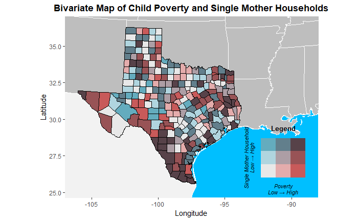

```r
final_map <- ggdraw() +
  draw_plot(mom_pov_map, x = 0, y = 0, width = 1, height = 1) +
  draw_plot(legend, x = 0.67, y = 0.10, width = 0.2, height = 0.35)

final_map
```

# 4 YOUR TURN!

Now it’s your turn! Although some of this might not be applicable to your thesis research, try this analysis on a dataset of your choice or recreate this analysis choosing a different state and poverty equation. If you can apply this to your thesis, then add it to your website! Otherwise create a new repository for your presentation on Thursday.